# Push-pull converter

For the push-pull converter shown in the figure, the input voltage is $40\,$V, the output voltage is $20\,$V, and the load resistance is $2\,\Omega$. The gate signals $g_1$ and $g_2$ are shown in the figure. The magnetizing inductance as seen from the source side is $5\,$mH (for each winding). The output capacitance is $20\,\mu$F, and the filter inductance is $500\,\mu$H. Determine the following.

1. the transformer turn ratio
2. peak voltage stress on switches $S_1$, $S_2$, and the rms values of $i_{S1}$, $i_{S2}$
3. peak voltage stress on diodes $D_1$, $D_2$, and the average values of $i_{D1}$, $i_{D2}$
4. ripple frequency of the inductor current

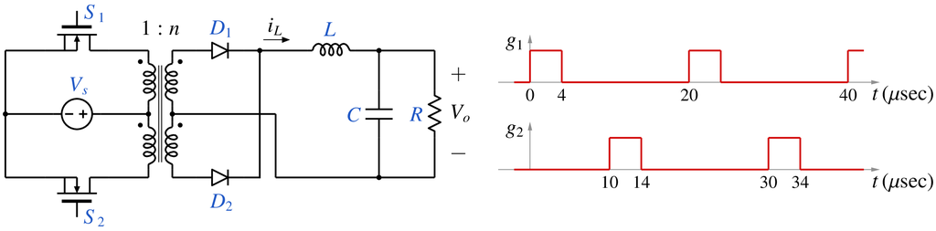

```python
from IPython.display import Image
Image(filename =r'push_pull_1_fig_1.png', width=750)
```

```python
# run this cell to view the circuit file.
%pycat push_pull_1_orig.in
```

We now replace the strings such as \$Vdc, \$L, with the values of our choice by running the python script given below. It takes an existing circuit file `push_pull_1_orig.in` and produces a new circuit file `push_pull_1.in`, after replacing \$Vdc, \$L, etc. with values of our choice.

```python
import gseim_calc as calc

s_Vdc = "40"
s_L = "500e-6"
s_R = "2"
s_C = "20e-6"
s_n = "2.0" # to be changed by user

f_hz = 50.0e3
T = 1/f_hz
s_Tend = "3e-3"
Tend = float(s_Tend)
T1 = Tend - 2.0*T
s_T1 = ("%11.4E"%(T1)).strip()

l = [
  ('$Vdc', s_Vdc),
  ('$L', s_L),
  ('$R', s_R),
  ('$C', s_C),
  ('$n', s_n),
  ('$Tend', s_Tend),
  ('$T1', s_T1),
]
calc.replace_strings_1("push_pull_1_orig.in", "push_pull_1.in", l)
print('push_pull_1.in is ready for execution')
```

```
push_pull_1.in is ready for execution
```

**Execute the following cell to run GSEIM on push_pull_1.in.**

```python
import os
import dos_unix
# uncomment for windows:
#dos_unix.d2u("push_pull_1.in")
os.system('run_gseim push_pull_1.in')
```

```
Circuit: filename = push_pull_1.in
main: calling solve_trns
Transient simulation starts...
i=0
i=10000
GSEIM: Program completed.
```

```
0
```

```
filename: push_pull_1_1.dat
filename: push_pull_1_2.dat
max stress on D1:  1.5986E+02 V
max stress on D2:  1.5986E+02 V
max stress on S1:  7.9968E+01 V
max stress on S2:  7.9968E+01 V
average ID1:  7.9928E+00 A
average ID2:  7.9892E+00 A
rms ID1:  9.4568E+00 A
rms ID2:  9.4538E+00 A
average IS1:  6.3889E+00 A
average IS2:  6.3960E+00 A
rms IS1:  1.4291E+01 A
rms IS2:  1.4299E+01 A
```

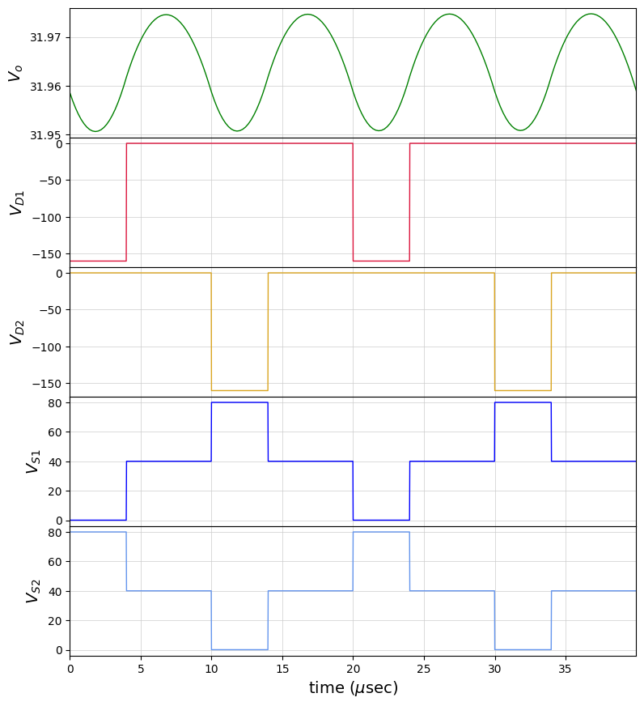

```python
import numpy as np
import matplotlib.pyplot as plt
import gseim_calc as calc
from setsize import set_size

slv = calc.slv("push_pull_1.in")

i_slv = 0
i_out = 0
filename = slv.l_filename_all[i_slv][i_out]
print('filename:', filename)
u = np.loadtxt(filename)
ta = u[:, 0]
t = ta - ta[0]

v_out = slv.get_array_double(i_slv,i_out,"v_out",u)
IL    = slv.get_array_double(i_slv,i_out,"IL"   ,u)
VD1   = slv.get_array_double(i_slv,i_out,"VD1"  ,u)
VD2   = slv.get_array_double(i_slv,i_out,"VD2"  ,u)
VS1   = slv.get_array_double(i_slv,i_out,"VS1"  ,u)
VS2   = slv.get_array_double(i_slv,i_out,"VS2"  ,u)

i_out = 1
filename = slv.l_filename_all[i_slv][i_out]
print('filename:', filename)
u1 = np.loadtxt(filename)
t1a = u1[:, 0]
t1 = t1a - t1a[0]

ID1 = slv.get_array_double(i_slv,i_out,"ID1",u1)
ID2 = slv.get_array_double(i_slv,i_out,"ID2",u1)
IS1 = slv.get_array_double(i_slv,i_out,"IS1",u1)
IS2 = slv.get_array_double(i_slv,i_out,"IS2",u1)

# since we have stored two cycles, we need to divide the last time point
# by 2 to get the period:

T = t[-1]/2

max_VD1 = -min(VD1)
max_VD2 = -min(VD2)
max_VS1 =  max(VS1)
max_VS2 =  max(VS2)

print('max stress on D1:', "%11.4E"%(max_VD1), 'V')
print('max stress on D2:', "%11.4E"%(max_VD2), 'V')
print('max stress on S1:', "%11.4E"%(max_VS1), 'V')
print('max stress on S2:', "%11.4E"%(max_VS2), 'V')

l_ID1 = calc.avg_rms_3a(t1, ID1, 0.0, 2.0*T, 1.0e-3*T)
l_ID2 = calc.avg_rms_3a(t1, ID2, 0.0, 2.0*T, 1.0e-3*T)
l_IS1 = calc.avg_rms_3a(t1, IS1, 0.0, 2.0*T, 1.0e-3*T)
l_IS2 = calc.avg_rms_3a(t1, IS2, 0.0, 2.0*T, 1.0e-3*T)

print('average ID1:', "%11.4E"%l_ID1[0], 'A')
print('average ID2:', "%11.4E"%l_ID2[0], 'A')
print('rms ID1:'    , "%11.4E"%l_ID1[1], 'A')
print('rms ID2:'    , "%11.4E"%l_ID2[1], 'A')
print('average IS1:', "%11.4E"%l_IS1[0], 'A')
print('average IS2:', "%11.4E"%l_IS2[0], 'A')
print('rms IS1:'    , "%11.4E"%l_IS1[1], 'A')
print('rms IS2:'    , "%11.4E"%l_IS2[1], 'A')

color1='green'
color2='crimson'
color3='goldenrod'
color4='blue'
color5='cornflowerblue'
color6='red'

fig, ax = plt.subplots(5, sharex=False)
plt.subplots_adjust(wspace=0, hspace=0.0)

set_size(7, 8, ax[0])

for i in range(5):
    ax[i].set_xlim(left=0, right=2.0*T*1e6)
    ax[i].grid(color='#CCCCCC', linestyle='solid', linewidth=0.5)

ax[0].plot(t*1e6, v_out, color=color1, linewidth=1.0, label="$V_o$")
ax[1].plot(t*1e6, VD1  , color=color2, linewidth=1.0, label="$V_{D1}$")
ax[2].plot(t*1e6, VD2  , color=color3, linewidth=1.0, label="$V_{D2}$")
ax[3].plot(t*1e6, VS1  , color=color4, linewidth=1.0, label="$V_{S1}$")
ax[4].plot(t*1e6, VS2  , color=color5, linewidth=1.0, label="$V_{S2}$")

ax[0].set_ylabel(r'$V_o$'   , fontsize=14)
ax[1].set_ylabel(r'$V_{D1}$', fontsize=14)
ax[2].set_ylabel(r'$V_{D2}$', fontsize=14)
ax[3].set_ylabel(r'$V_{S1}$', fontsize=14)
ax[4].set_ylabel(r'$V_{S2}$', fontsize=14)

ax[4].set_xlabel('time (' + r'$\mu$' + 'sec)', fontsize=14)

#ax[0].legend(loc = 'lower right',frameon = True, fontsize = 10, title = None,
#   markerfirst = True, markerscale = 1.0, labelspacing = 0.5, columnspacing = 2.0,
#   prop = {'size' : 12},)

for i in range(4):
    ax[i].tick_params(labelbottom=False)

#plt.tight_layout()
plt.show()
```

```
filename: push_pull_1_1.dat
filename: push_pull_1_2.dat
```

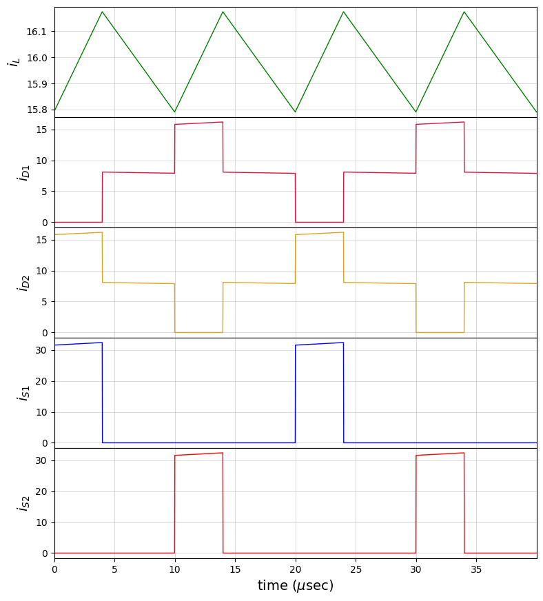

```python
import numpy as np
import matplotlib.pyplot as plt
import gseim_calc as calc
from setsize import set_size

slv = calc.slv("push_pull_1.in")

i_slv = 0
i_out = 0
filename = slv.l_filename_all[i_slv][i_out]
print('filename:', filename)
u = np.loadtxt(filename)
ta = u[:, 0]
t = ta - ta[0]

IL = slv.get_array_double(i_slv,i_out,"IL",u)

i_out = 1
filename = slv.l_filename_all[i_slv][i_out]
print('filename:', filename)
u1 = np.loadtxt(filename)
t1a = u1[:, 0]
t1 = t1a - t1a[0]

ID1 = slv.get_array_double(i_slv,i_out,"ID1",u1)
ID2 = slv.get_array_double(i_slv,i_out,"ID2",u1)
IS1 = slv.get_array_double(i_slv,i_out,"IS1",u1)
IS2 = slv.get_array_double(i_slv,i_out,"IS2",u1)

# since we have stored two cycles, we need to divide the last time point
# by 2 to get the period:

T = t[-1]/2

color1='green'
color2='crimson'
color3='goldenrod'
color4='blue'
color5='red'

fig, ax = plt.subplots(5, sharex=False)
plt.subplots_adjust(wspace=0, hspace=0.0)

set_size(7, 8, ax[0])

for i in range(5):
    ax[i].set_xlim(left=0, right=2.0*T*1e6)
    ax[i].grid(color='#CCCCCC', linestyle='solid', linewidth=0.5)

ax[0].plot(t*1e6, IL, color=color1, linewidth=1.0, label="$i_L$")

ax[1].plot(t1*1e6, ID1, color=color2, linewidth=1.0, label="$i_{D1}$")
ax[2].plot(t1*1e6, ID2, color=color3, linewidth=1.0, label="$i_{D2}$")
ax[3].plot(t1*1e6, IS1, color=color4, linewidth=1.0, label="$i_{S1}$")
ax[4].plot(t1*1e6, IS2, color=color5, linewidth=1.0, label="$i_{S2}$")

ax[0].set_ylabel(r'$i_L$'   , fontsize=14)
ax[1].set_ylabel(r'$i_{D1}$', fontsize=14)
ax[2].set_ylabel(r'$i_{D2}$', fontsize=14)
ax[3].set_ylabel(r'$i_{S1}$', fontsize=14)
ax[4].set_ylabel(r'$i_{S2}$', fontsize=14)

ax[4].set_xlabel('time (' + r'$\mu$' + 'sec)', fontsize=14)

#ax[0].legend(loc = 'lower right',frameon = True, fontsize = 10, title = None,
#   markerfirst = True, markerscale = 1.0, labelspacing = 0.5, columnspacing = 2.0,
#   prop = {'size' : 12},)

for i in range(4):
    ax[i].tick_params(labelbottom=False)

#plt.tight_layout()
plt.show()
```

This notebook was contributed by **Prof. Nakul Narayanan K**, Govt. Engineering College, Thrissur. He may be contacted at nakul@gectcr.ac.in.